# Actividad1_Transporte

Author

Camila

## Running Code

```r
install.packages("bnlearn")
```

## Librerías

```r
library(bnlearn)
```

## Abrir los datos

```r
data = read.csv("../data/survey.csv", stringsAsFactors = TRUE)
head(data)
```

| A | R | E | O | S | T |
| --- | --- | --- | --- | --- | --- |
| adult | big | high | yes | F | car |
| adult | small | uni | yes | M | car |
| adult | big | uni | yes | F | train |
| adult | big | high | yes | M | car |
| adult | big | high | yes | M | car |
| adult | small | high | yes | F | train |

# Hacer una dag

Crear DAG vacía

```r
dag = empty.graph(nodes = c("A", "S", "E", "O", "R", "T"))
```

- Definir las relaciones con una matriz.

```r
arc_set = matrix(c("A", "E",
                   "S", "E",
                   "E", "O",
                   "E", "R",
                   "O", "T",
                   "R", "T"), byrow = TRUE, ncol = 2,
                 dimnames = list(NULL, c("from", "to")))
```

## **Creando la DAG**

- La primera columna define el nodo padre y la segunda el hijo.

```r
arc_set
```

```
     from to
[1,] "A"  "E"
[2,] "S"  "E"
[3,] "E"  "O"
[4,] "E"  "R"
[5,] "O"  "T"
[6,] "R"  "T"
```

- Creamos los arcos de la DAG con la función `arc()`.

```r
arcs(dag) = arc_set
```

objeto resultante

```r
dag
```

```
  Random/Generated Bayesian network

  model:
   [A][S][E|A:S][O|E][R|E][T|O:R]
  nodes:                                 6
  arcs:                                  6
    undirected arcs:                     0
    directed arcs:                       6
  average markov blanket size:           2.67
  average neighbourhood size:            2.00
  average branching factor:              1.00

  generation algorithm:                  Empty
```

## **Estimando los parámetros**

- Utilizamos el método de máxima verosimilitud (MLE) para estimar los parámetros de nuestra DAG.

```r
bn_mle = bn.fit(dag, data = data, method = "mle")
```

- Para acceder a las probabilidades condicionales usamos el operador `$` y el nombre del nodo.
- Obtenemos las probabilidades condicionales del nodo de educación.

```r
bn_mle$E
```

```
  Parameters of node E (multinomial distribution)

Conditional probability table:

, , S = F

      A
E          adult       old     young
  high 0.6391753 0.8461538 0.5384615
  uni  0.3608247 0.1538462 0.4615385

, , S = M

      A
E          adult       old     young
  high 0.7194245 0.8923077 0.8105263
  uni  0.2805755 0.1076923 0.1894737
```

## **Probabilidades condicionales**

```r
bn_mle$A
```

```
  Parameters of node A (multinomial distribution)

Conditional probability table:
 adult   old young
0.472 0.208 0.320
```

2. ¿Cuál es la probabilidad de que una persona con educación universitaria trabaje?

```r
bn_mle$O
```

```
  Parameters of node O (multinomial distribution)

Conditional probability table:

     E
O           high        uni
  no  0.01917808 0.07407407
  yes 0.98082192 0.92592593
```

- Por lo tanto, la probabilidad estimada es de alrededor 0.9259.

## **Pruebas de independencia condicional**

- Prueba $G^2$: Equivalente a la prueba de información mutua (`mi`).

```r
ci.test("T", "E", c("O", "R"), test = "mi", data = data)
```

```
    Mutual Information (disc.)

data:  T ~ E | O + R
mi = 9.8836, df = 8, p-value = 0.2733
alternative hypothesis: true value is greater than 0
```

- P-values grandes $\Longrightarrow$ **No** rechazar la hipótesis nula.
- No hay evidencia que sugiera que $T$ depende de $E$ dados $O$ y $R$.
- La relación de dependencia E→TE→T no es significativa dada la estructura de la DAG actual.
- **No hay arco de** $E$ a $T$

¿El transporte será independiente de la ocupación dada la residencia?

$$H_0 : T \perp\!\!\!\perp O \mid R \qquad H_a : T \not\!\perp\!\!\!\perp O \mid R$$

```r
 ci.test("T", "O", "R", test = "mi", data = data)
```

```
    Mutual Information (disc.)

data:  T ~ O | R
mi = 4.7669, df = 4, p-value = 0.3121
alternative hypothesis: true value is greater than 0
```

- **No** rechazamos $H_0$: Transporte es condicionalmente independiente de la ocupación dada la residencia.
- La relación de dependencia $O \rightarrow T$ **no** es significativa.
- **No debería haber arco de** $O$ a $T$

## **Estructura de la DAG**

```r
arc.strength(dag, data = data, criterion = "mi")
```

| from | to | strength |
| --- | --- | --- |
| A | E | 0.0005273 |
| S | E | 0.0013194 |
| E | O | 0.0050317 |
| E | R | 0.0003125 |
| O | T | 0.3120664 |
| R | T | 0.0008180 |

### Bic

```r
score(dag, data = data, type = "bic")
```

```
[1] -2012.687
```

### Akaike

```r
score(dag, data = data, type = "aic")
```

```
[1] -1968.433
```

## Best dag

```r
best_dag = hc(data)
```

```r
modelstring(best_dag)
```

```
[1] "[R][E|R][T|R][A|E][O|E][S|E]"
```

### Score

```r
score(best_dag, data = data, type = "bic")
```

```
[1] -1998.432
```

```r
score(best_dag, data = data, type = "aic")
```

```
[1] -1966.823
```

- Estos valores son más grandes que los que obtuvimos antes.
- Esta estructura resulta ser mejor.

### Graficar

```r
install.packages("BiocManager")
BiocManager::install("Rgraphviz")
```

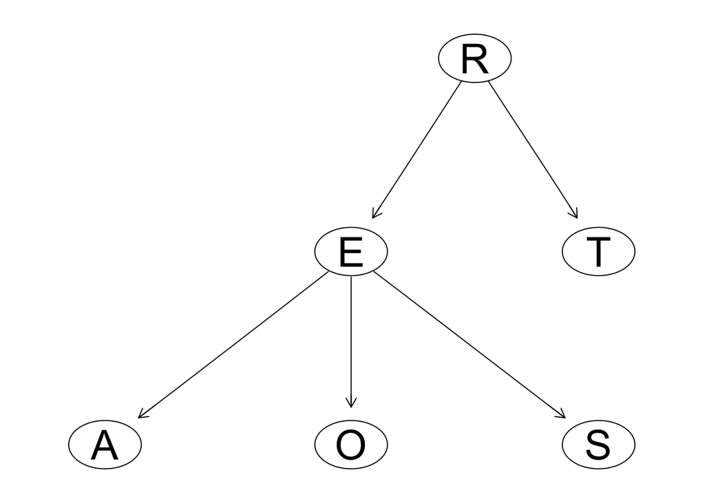

```r
graphviz.plot(best_dag, shape = "ellipse")
```

# Queries

## Logic Sampling

- Ajustamos una red bayesina usando la DAG óptima que resultó del algoritmo hill-climbing.

```r
best_dag = hc(data)
```

```r
bn = bn.fit(best_dag, data = data)
```

```r
cpquery(bn, event= (T == "train" & S == "F"), evidence= (E == "uni"), n= 10^6)
```

```
[1] 0.1230279
```

## Likelihood Weighting

```r
cpquery(bn, event= (T == "train" & S == "F"), evidence= list(E = "uni"), method = "lw")
```

```
[1] 0.1249486
```

## Otros Queries

La Secretaría de Transporte de Jalisco está interesada en conocer si hombres jalisciences se transportan más en tren cuando son jóvenes universitarios o adultos (sin importar su educación) que las mujeres jalisciences con las mismas características

$p_M = \mathbb{P}(T= train | \{(A= young \cap E = uni)\cup A = adult) \} \cap S= male)$

$p_F = \mathbb{P}(T= train | \{(A= young \cap E = uni)\cup A = adult) \} \cap S= female)$

$$p_M > p_F$$

```r
cpquery(bn, event= (T == "train"), evidence= ((S == "M") & (((A == "young") & (E == "uni")) | (A == "adult"))), n = 10^6)
```

```
[1] 0.2481619
```

```r
cpquery(bn, event= (T == "train"), evidence= ((S == "F") & (((A == "young") & (E == "uni")) | (A == "adult"))), n = 10^6)
```

```
[1] 0.2453524
```

- La probabilidad parece ser ligeramente mayor en los hombres, salvo el error de simulación.